# Extensions to the Grammar of Graphics

### position_fillnudge()

Here we nudge the labels down from the top of each stacked bar with `vjust = 1`.

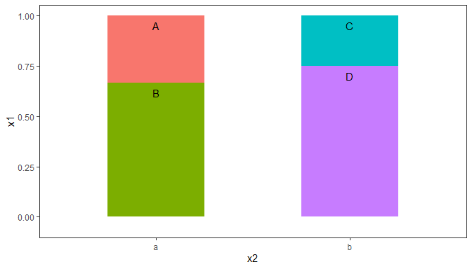

```r
 ggplot(data = subset(df, x1 >= 0), aes(x2, x1, group = grp)) +
   geom_col(aes(fill = grp), width=0.5, position = position_fill()) +
   geom_vline(xintercept = 0) +
   geom_text(
     aes(label = grp),
     position = position_fillnudge(vjust = 1, y = -0.05)) +
   theme(legend.position = "none")
```

### position_jitternudge()

When combining jitter and nudge, we can nudge away from the jittered positions or from the original positions. In this example, nudge away from the jittered positions with `nudge.from = "jittered"` nad the direction of the nudge is on either side of the original position with `direction = "split"`, with nudging depending on the direction the jitter has moved the point.

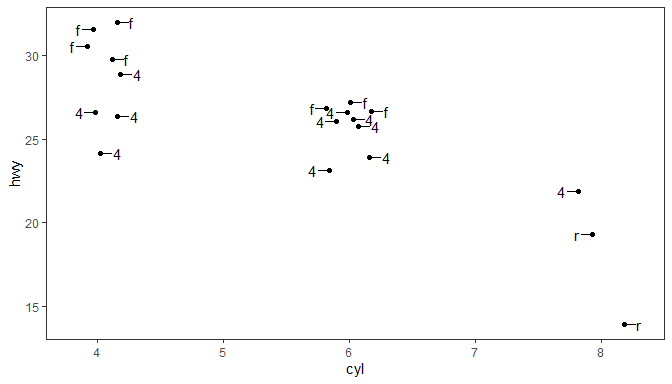

```r
 jitter <- position_jitter(width = 0.2, height = 2, seed = 123)

 jitter_nudge <- position_jitternudge(width = 0.2, height = 2,
                                      seed = 123, x = 0.1,
                                      direction = "split",
                                      nudge.from = "jittered")
 ggplot(mpg[1:20, ],
        aes(cyl, hwy, label = drv)) +
   geom_point(position = jitter) +
   geom_text_s(position = jitter_nudge)
```

In this second example, the nudging is away from the original *x*-position and the jittered *y*-position, which gives vertically aligned labels.

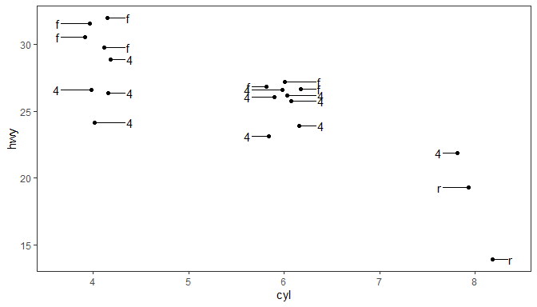

```r
jitter <- position_jitter(width = 0.2, height = 2, seed = 123)

jitter_nudge <- position_jitternudge(width = 0.2, height = 2,
                                      seed = 123, x = 0.35,
                                      direction = "split",
                                      nudge.from = "original.x")
 ggplot(mpg[1:20, ],
        aes(cyl, hwy, label = drv)) +
   geom_point(position = jitter) +
   geom_text_s(position = jitter_nudge)
```

### position_jitter_keep()

With no nudging but keeping the original positions we show how points have moved with jitter.

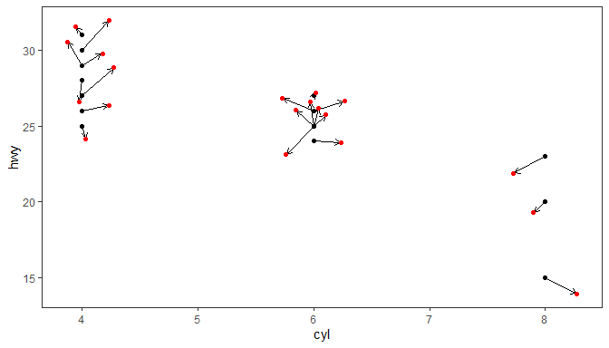

```r
 ggplot(mpg[1:20, ],
        aes(cyl, hwy, label = drv)) +
   geom_point() +
   geom_point_s(position =
                position_jitter_keep(width = 0.3, height = 2, seed = 123),
                color = "red")
```

## Appendix A: More on density filtering

We define a function to simplify the generation of random data sets based on different probability distributions.

```r
make_data_tbl <- function(nrow = 100, rfun = rnorm, ...) {
  if (nrow %% 2) {
    nrow <- nrow + 1
  }

  set.seed(1001)

  tibble::tibble(
    x = rfun(nrow, ...),
    y = rfun(nrow, ...),
    group = rep(c("A", "B"), c(nrow / 2, nrow / 2))
  )
}
```

In all the examples in this vignette we use colors to demonstrate which data points are selected, but any other suitable aesthetic and discrete scale can be used instead. With `keep.sparse = FALSE` we keep 1/3 of the observations in the denser region of the plot. Although here we first plot all data points and later overplot the selected ones this is not necessary.

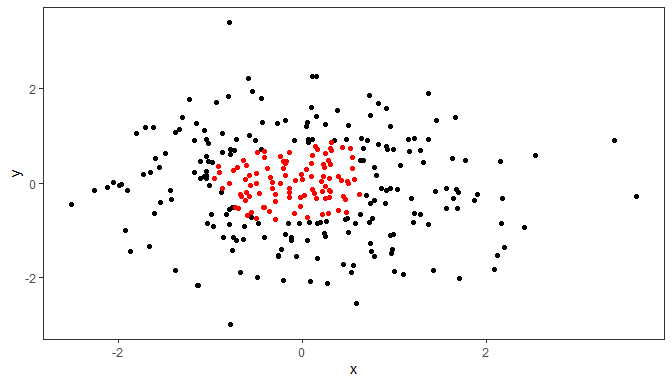

```r
ggplot(data = make_data_tbl(300), aes(x, y)) +
  geom_point() +
  stat_dens2d_filter(colour = "red",
                     keep.sparse = FALSE,
                     keep.fraction = 1/3)
```

Here we highlight the observations split in three group equal groups, each of a different density of observations.

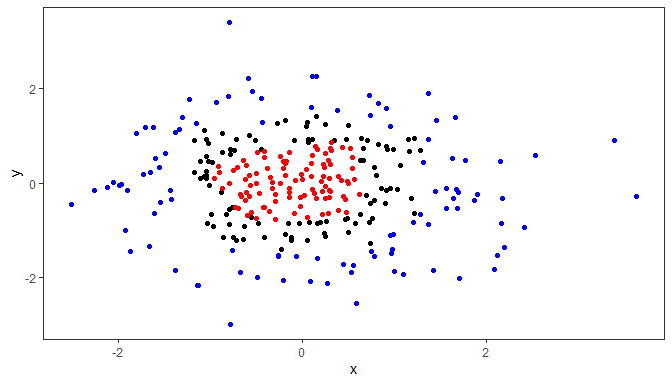

```r
ggplot(data = make_data_tbl(300), aes(x, y)) +
  geom_point() +
  stat_dens2d_filter(colour = "red",
                     keep.sparse = FALSE,
                     keep.fraction = 1/3)+
  stat_dens2d_filter(colour = "blue",
                     keep.fraction = 1/3)
```

The algorithm seems to work well also with other distributions, in this example the uniform distribution.

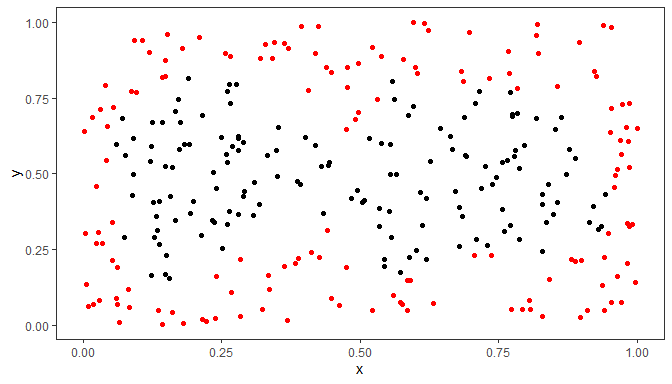

```r
ggplot(data = make_data_tbl(300, rfun = runif), aes(x, y)) +
  geom_point() +
  stat_dens2d_filter(colour = "red", keep.fraction = 1/2)
```

One example with the gamma distribution, which is asymmetric.

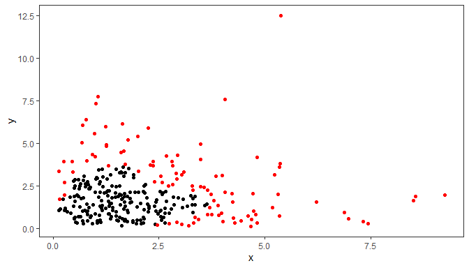

```r
ggplot(data = make_data_tbl(300, rfun = rgamma, shape = 2),
       aes(x, y)) +
  geom_point() +
  stat_dens2d_filter(colour = "red", keep.fraction = 1/3)
```

## Appendix B: try_tibble()

### Time series

Several different formats for storing time series data are used in R. Here we use in the examples objects of class `ts` but several other classes are supported as `try.xts()` is used internally. The first example is a quarterly series.

```r
class(austres)
```

```
## [1] "ts"
```

```r
austres.df <- try_tibble(austres)
class(austres.df)
```

```
## [1] "tbl_df"     "tbl"        "data.frame"
```

```r
head(austres.df, 4)
```

```
## # A tibble: 4 × 2
##   time            x
##   <date>      <dbl>
## 1 1971-04-01 13067.
## 2 1971-07-01 13130.
## 3 1971-10-01 13198.
## 4 1972-01-01 13254.
```

The next chunk demonstrates that numeric times are expressed as decimal years in the returned data frame.

```r
austres.df <- try_tibble(austres, as.numeric = TRUE)
head(austres.df, 4)
```

```
## # A tibble: 4 × 2
##    time      x
##   <dbl>  <dbl>
## 1 1971. 13067.
## 2 1971. 13130.
## 3 1972. 13198.
## 4 1972  13254.
```

This second example is for a series of yearly values.

```r
class(lynx)
```

```
## [1] "ts"
```

```r
lynx.df <- try_tibble(lynx)
class(lynx.df)
```

```
## [1] "tbl_df"     "tbl"        "data.frame"
```

```r
head(lynx.df, 3)
```

```
## # A tibble: 3 × 2
##   time           x
##   <date>     <dbl>
## 1 1821-01-01   269
## 2 1822-01-01   321
## 3 1823-01-01   585
```

Above there is a small rounding error of 1 s for these old dates. We can correct this by rounding to year.

```r
lynx.df <- try_tibble(lynx, "year")
head(lynx.df, 3)
```

```
## # A tibble: 3 × 2
##   time           x
##   <date>     <dbl>
## 1 1821-01-01   269
## 2 1822-01-01   321
## 3 1823-01-01   585
```

In addition we can convert the POSIXct values into numeric values in calendar years plus a decimal fraction.

```r
lynx_n.df <- try_tibble(lynx, "year", as.numeric = TRUE)
lapply(lynx_n.df, "class")
```

```
## $time
## [1] "numeric"
##
## $x
## [1] "numeric"
```

```r
head(lynx_n.df, 3)
```

```
## # A tibble: 3 × 2
##    time     x
##   <dbl> <dbl>
## 1  1821   269
## 2  1822   321
## 3  1823   585
```

### Other classes

`try_tibble()` attempts to handle gracefully objects that are not time series.

```r
try_tibble(1:5)
```

```
## # A tibble: 5 × 1
##       x
##   <int>
## 1     1
## 2     2
## 3     3
## 4     4
## 5     5
```

```r
try_tibble(letters[1:5])
```

```
## # A tibble: 5 × 1
##   x
##   <chr>
## 1 a
## 2 b
## 3 c
## 4 d
## 5 e
```

```r
try_tibble(factor(letters[1:5]))
```

```
## # A tibble: 5 × 1
##   x
##   <fct>
## 1 a
## 2 b
## 3 c
## 4 d
## 5 e
```

```r
try_tibble(list(x = rep(1,5), y = 1:5))
```

```
## # A tibble: 5 × 2
##       x     y
##   <dbl> <int>
## 1     1     1
## 2     1     2
## 3     1     3
## 4     1     4
## 5     1     5
```

```r
try_tibble(data.frame(x = rep(1,5), y = 1:5))
```

```
## # A tibble: 5 × 2
##       x     y
##   <dbl> <int>
## 1     1     1
## 2     1     2
## 3     1     3
## 4     1     4
## 5     1     5
```

```r
try_tibble(matrix(1:10, ncol = 2))
```

```
## # A tibble: 5 × 2
##      V1    V2
##   <int> <int>
## 1     1     6
## 2     2     7
## 3     3     8
## 4     4     9
## 5     5    10
```